# IE 582 Homework 02 - Dorukhan Kılınç 2017402093

```python
import numpy as np
import pandas as pd
import matplotlib.pyplot as plt
from sklearn.decomposition import PCA
from sklearn.manifold import MDS
from sklearn.metrics.pairwise import manhattan_distances
```

## Task 1

### Part a

```python
data_q1 = pd.read_csv("IE582_Fall21_HW2_q1_data.csv")
data_q1
```

|  | X1 | X2 | class |
| --- | --- | --- | --- |
| 0 | 0.569483 | 0.822003 | a |
| 1 | 0.411469 | 0.911424 | a |
| 2 | 0.417385 | -0.908730 | a |
| 3 | -0.791828 | 0.610745 | a |
| 4 | -0.806777 | -0.590857 | a |
| ... | ... | ... | ... |
| 193 | -0.662932 | 1.886934 | b |
| 194 | 0.316428 | 1.974810 | b |
| 195 | -1.625464 | -1.165275 | b |
| 196 | -1.378755 | -1.448804 | b |
| 197 | -1.005258 | -1.729005 | b |

198 rows × 3 columns

```python
pca = PCA()
principalComponents = pca.fit_transform(data_q1.drop(columns = "class"))
principalDf = pd.DataFrame(data = principalComponents[:,0]
             , columns = ['principal component'])
finalDf = pd.concat([principalDf, data_q1[['class']]], axis = 1)
```

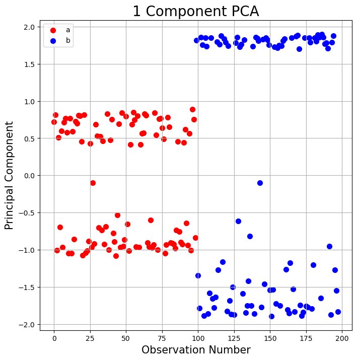

```python
fig = plt.figure(figsize = (8,8))

plt.xlabel('Observation Number', fontsize = 15)
plt.ylabel('Principal Component', fontsize = 15)
plt.title('1 Component PCA', fontsize = 20)
targets = ['a', 'b']
colors = ['r', 'b']

class_a = []
class_b = []
for i in range(len(finalDf)):
    if finalDf.loc[i, "class"] == "a": class_a.append(i)
    else: class_b.append(i)

plt.scatter(class_a, finalDf.loc[class_a, 'principal component']
               , c = "r"
               , s = 50)

plt.scatter(class_b, finalDf.loc[class_b, 'principal component']
               , c = "b"
               , s = 50)

plt.legend(targets)
plt.grid()
plt.show();
```

### Part b

```python
embedding1 = MDS(n_components=1, random_state=0)
data_transformed1 = embedding1.fit_transform(data_q1.drop(columns = "class"))
MDSDf1 = pd.DataFrame(data = data_transformed1
             , columns = ['MDS'])
MDSfinalDf1 = pd.concat([MDSDf1, data_q1[['class']]], axis = 1)

embedding2 = MDS(n_components=1, dissimilarity='precomputed', random_state=0)
data_transformed2 = embedding1.fit_transform(manhattan_distances(data_q1.drop(columns = "class")))
MDSDf2 = pd.DataFrame(data = data_transformed2
             , columns = ['MDS'])
MDSfinalDf2 = pd.concat([MDSDf2, data_q1[['class']]], axis = 1)
```

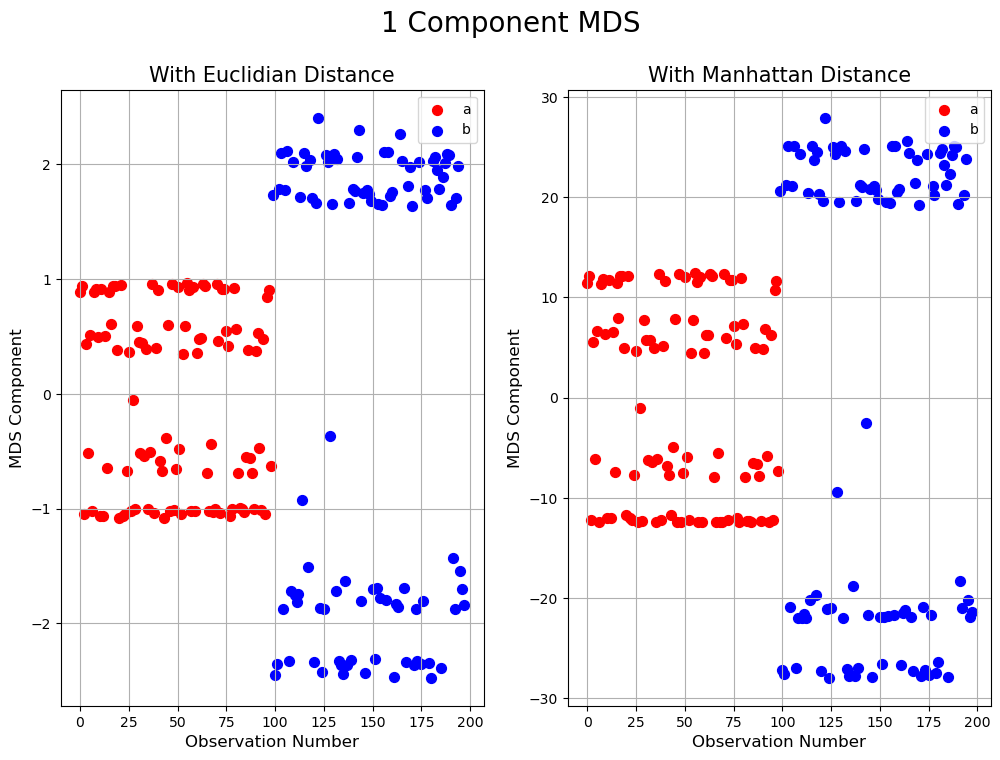

```python
fig, ax = plt.subplots(1, 2, figsize=(12,8), sharey = False)

ax[0].set_xlabel('Observation Number', fontsize = 12)
ax[0].set_ylabel('MDS Component', fontsize = 12)

ax[1].set_xlabel('Observation Number', fontsize = 12)
ax[1].set_ylabel('MDS Component', fontsize = 12)

fig.suptitle('1 Component MDS', fontsize = 20)

ax[0].set_title("With Euclidian Distance", fontsize =15)
ax[0].scatter(class_a, MDSfinalDf1.loc[class_a, 'MDS']
               , c = "r"
               , s = 50)

ax[0].scatter(class_b, MDSfinalDf1.loc[class_b, 'MDS']
               , c = "b"
               , s = 50)

ax[1].set_title("With Manhattan Distance", fontsize =15)
ax[1].scatter(class_a, MDSfinalDf2.loc[class_a, 'MDS']
               , c = "r"
               , s = 50)

ax[1].scatter(class_b, MDSfinalDf2.loc[class_b, 'MDS']
               , c = "b"
               , s = 50)


ax[0].legend(targets)
ax[1].legend(targets)

ax[0].grid()
ax[1].grid()
plt.show();
```

### Part c

#### 1.

```python
print(pca.explained_variance_[0])
print(pca.explained_variance_ratio_[0])
```

```
1.7908997545127665
0.7194375335021417
```

Here above are the explained variance and explained variance ratio we get by using PCA. Notice that the ratio is very high. That can also be seen visually by looking at the plot from part a. Apart from a few outliers, PCA successfully seperates a and b classes. Instances of class "a" have smaller absolute values than that of class "b", reflecting the inner circle - outer circle difference that can be seen from the original 2d plot.

#### 2.

Referring to the plots from part b, we can say that both did a well job in seperating the classes, there only are some minor differences and a scale difference.

#### 3.

Graphically speaking, all models did very good in dimensionality reduction in the sense that the class information is still visible.

### Part d

```python
data_q1_new = data_q1.copy()

data_q1_new["X1^2"] = data_q1_new["X1"]**2
data_q1_new["X2^2"] = data_q1_new["X2"]**2
data_q1_new["X1X2"] = data_q1_new["X1"]*data_q1_new["X2"]
```

```python
pca2 = PCA()
principalComponents2 = pca2.fit_transform(data_q1_new.drop(columns = "class"))
principalDf2 = pd.DataFrame(data = principalComponents2)
finalDf2 = pd.concat([principalDf2, data_q1_new[['class']]], axis = 1)
finalDf2
```

|  | 0 | 1 | 2 | 3 | 4 | class |
| --- | --- | --- | --- | --- | --- | --- |
| 0 | -0.139714 | -0.300223 | -1.253871 | -0.832173 | 0.486491 | a |
| 1 | 0.051931 | -0.300438 | -1.260008 | -0.734355 | 0.278286 | a |
| 2 | -1.190015 | -0.807435 | 0.007729 | -0.650498 | -0.406087 | a |
| 3 | -0.581394 | -0.550799 | -1.346118 | 0.704651 | -0.112335 | a |
| 4 | -1.534138 | 0.355528 | -0.830090 | 0.126772 | -0.307266 | a |
| ... | ... | ... | ... | ... | ... | ... |
| 193 | 2.556107 | -0.511332 | 0.183222 | 1.121244 | -0.379766 | b |
| 194 | 2.839625 | 0.697316 | 0.086487 | -0.586371 | 0.119510 | b |
| 195 | -1.827882 | 2.525337 | 0.267090 | 1.010866 | 0.793714 | b |
| 196 | -1.383142 | 2.617764 | 0.774818 | 0.398656 | 0.152085 | b |
| 197 | -0.769885 | 2.366587 | 1.446011 | -0.212074 | -0.627894 | b |

198 rows × 6 columns

```python
print(pca.explained_variance_[0])
print(pca2.explained_variance_)
print(pca.explained_variance_ratio_[0])
print(pca2.explained_variance_ratio_)
```

```
1.7908997545127665
[2.49086525 1.44256642 1.28808119 0.54559809 0.30619998]
0.7194375335021417
[0.410133   0.23752553 0.21208879 0.08983536 0.05041731]
```

Here above are the explanied variance with the first pca model, explanied variance with the second pca model, i.e. the eigenvalues, and corresponding ratios. Notice that the introduction of the new features decreased the success of the individual components in terms of the explained variance because now there are 5 dimensions to explain.

## Task 2

```python
data_q2 = pd.read_excel("ilmesafe.xls", skiprows = 2)
M = np.array(data_q2.drop(columns = ["İL PLAKA NO", "İL ADI"]))
np.fill_diagonal(M,0)
for i in range(81):
    for j in range(i, 81):
        M[j,i] = M[i,j]
city_names = data_q2["İL ADI"]
```

```python
embedding3 = MDS(random_state=0)
#embedding3 = MDS(dissimilarity='precomputed')
data_transformed3 = embedding3.fit_transform(M)
```

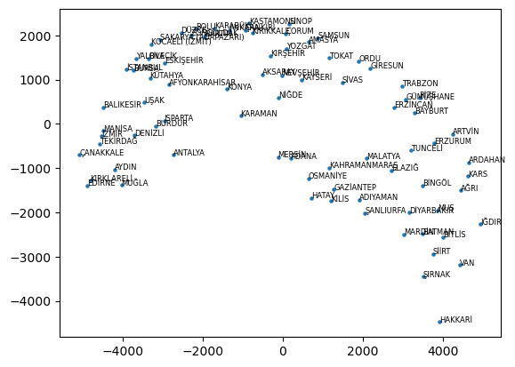

```python
plt.scatter(data_transformed3[:,1], data_transformed3[:,0], s = 5)

for i in range(81):
    plt.text(x = data_transformed3[i,1], y = data_transformed3[i,0],
             s = city_names[i], size = 6)

plt.show();
```

Although MDS kept the city to city orientation, i.e. relative directions of each cities with respect to each other, the general map seems to be distorted version of the original map. This may be because the uneven distribution of natural factors such as mountains, rivers, etc. incrasee the distance between some cities more than they do to the others. Notice that the eastern cities are mapped to the south-eastern region, reflecting the increase in mountains in the eastern regions of Turkey.

## Task 3

### Part a

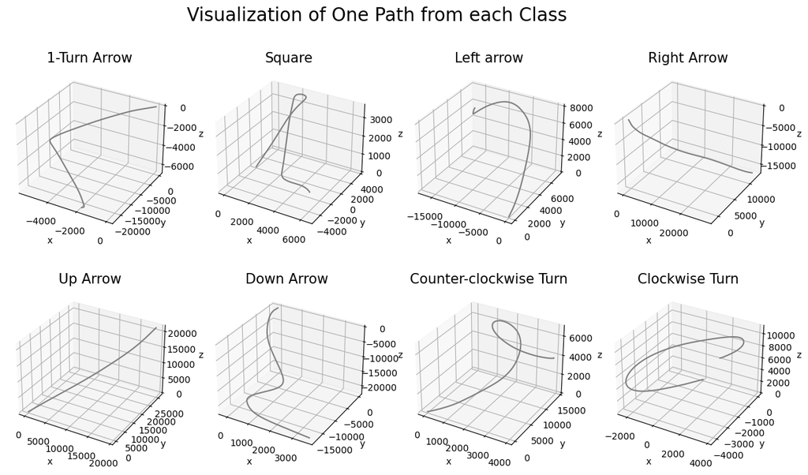

```python
file_names = ["uWaveGestureLibrary_X_TRAIN",
              "uWaveGestureLibrary_Y_TRAIN",
              "uWaveGestureLibrary_Z_TRAIN"]

data = [[], [], []]

for i in range(3):
    for line in open(file_names[i]):
        data[i].append(line.split())
    data[i] = np.array(data[i])

data_acc = np.ndarray(shape = (896, 316, 3), dtype = "float")

for i in range(3):
    data_acc[:,:, i] = data[i]

data_v = np.zeros(shape = (896, 316, 3))

data_v[:,0,:] = data_acc[:,0,:]

for instance in range(896):
    for time in range(2, 316):
        data_v[instance, time, :] = data_v[instance, time - 1,:] + data_acc[instance, time - 1,:]

data_dist = np.zeros(shape = (896, 316, 3))
data_dist[:,0,:] = data_acc[:,0,:]

for instance in range(896):
    for time in range(2, 316):
        data_dist[instance, time, :] = data_dist[instance, time - 1,:] + data_v[instance, time - 1,:] + data_acc[instance, time - 1,:]/2

instances = []

for c in range(1,9):
    for instance in range(896):
        if data_v[instance,0,0] == c:
            instances.append(instance)
            break
fig = plt.figure(figsize= (15,8))

labels =["1-Turn Arrow", "Square", "Left arrow", "Right Arrow",
        "Up Arrow", "Down Arrow ", "Counter-clockwise Turn", "Clockwise Turn"]
for i in range(2):
    for j in range(4):
        ax = fig.add_subplot(2, 4, i*4 + j + 1, projection='3d')
        ax.plot(data_dist[instances[i*4 + j], 1:, 0],
                       data_dist[instances[i*4 + j], 1:, 1],
                       data_dist[instances[i*4 + j], 1:, 2],
                       'gray')
        ax.set_title(labels[i*4 + j], size =15)
        ax.set_xlabel('x')
        ax.set_ylabel('y')
        ax.set_zlabel('z')

fig.suptitle("Visualization of One Path from each Class",size = 20)

plt.show();
```

The class labels for each instance is in accordance with the numbers given in the homework. I decided on what class each instance belongs to by basically visualizing the path each instance follows and try to find the moves it makes. To construct the paths, I used basic physics knowledge to find the path from the acceleration data, i.e. $V_{t} = V_{t-1} + a_{t-1}\Delta t$ and $X_{t} = X_{t-1} + V_{t-1}\Delta t + \frac{1}{2}a_{t-1}(\Delta t)^2$. It should be noted that the t-1 velocity and acceleration used to calculate $X_{t}$ since we don't have continuous acceleration data. Furthermore, for easiness, I assumed $\Delta t = 1$. Therefore the equations became:

$V_{t} = V_{t-1} + a_{t-1}$

$X_{t} = X_{t-1} + V_{t-1} + \frac{1}{2}a_{t-1}$

Note that I assumed that $X_{t = 0} = (0, 0, 0)$.Here is some further explanation about why I labeled instances in the way I did:

Class 1: Since the path takes a sharp turn and in none of the other classes there is only one sharp turn

Class 2: Since the path takes three sharp turns.

Class 5: Since the path moves in the +z direction.

Class 6: Since the path moves in the -z direction.

### Part b

```python
class_indexes = [[],[],[],[],
    [],[],[],[]]

for c in range(8):
    for instance in range(896):
        if(data_dist[instance,0,0] == c + 1): class_indexes[c].append(instance)

class_instances = []

data_dist_x = data_dist[:,1:,0]
data_dist_y = data_dist[:,1:,1]
data_dist_z = data_dist[:,1:,2]

data_dist_concatenated = []

for instance in range(896):
    data_dist_concatenated.append(np.concatenate((data_dist_x[instance,:],
                                           data_dist_y[instance,:],
                                           data_dist_z[instance,:])))

for c in range(8):
    a = []
    for i in class_indexes[c]:
        a.append(data_dist_concatenated[i])
    class_instances.append(a)
```

```python
pca_models = []

for c in range(8):
    pca_new = PCA()
    pca_new.fit_transform(class_instances[c])
    pca_models.append(pca_new)
```

```python
for c in range(8):
    print("For class: " + str(c+1))
    print("Explained variability: " + str(pca_models[c].explained_variance_[:2]))
    print("Explained variability ratio: " + str(pca_models[c].explained_variance_ratio_[:2]))
```

```
For class: 1
Explained variability: [9.43604750e+09 4.95037117e+09]
Explained variability ratio: [0.48732473 0.25566195]
For class: 2
Explained variability: [3.35572829e+09 1.58153326e+09]
Explained variability ratio: [0.53990275 0.25445271]
For class: 3
Explained variability: [2.19570792e+10 1.76003831e+10]
Explained variability ratio: [0.48955873 0.3924211 ]
For class: 4
Explained variability: [2.81596643e+10 1.81921578e+10]
Explained variability ratio: [0.54996601 0.35529786]
For class: 5
Explained variability: [3.53487458e+10 8.36621920e+09]
Explained variability ratio: [0.76558352 0.18119567]
For class: 6
Explained variability: [4.48812319e+10 2.68136849e+10]
Explained variability ratio: [0.56101812 0.33517269]
For class: 7
Explained variability: [1.62213856e+10 4.25871318e+09]
Explained variability ratio: [0.69919682 0.183565  ]
For class: 8
Explained variability: [8.13972466e+09 4.91763026e+09]
Explained variability ratio: [0.52438203 0.31680641]
```

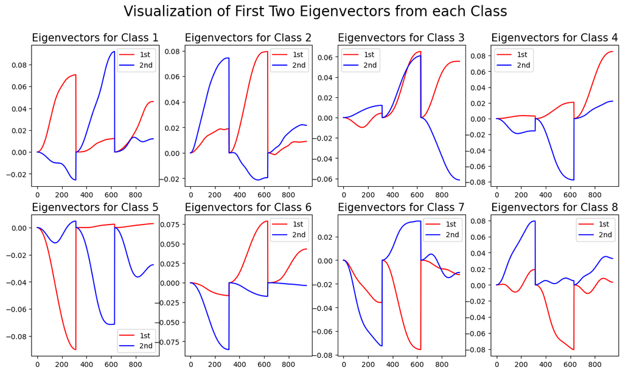

```python
fig = plt.figure(figsize= (15,8))

for i in range(8):
    ax = fig.add_subplot(2, 4, i+1)
    ax.set_title("Eigenvectors for Class "+str(i+1), size =15)
    ax.plot(pca_models[i].components_[0], c = "r")
    ax.plot(pca_models[i].components_[1], c = "b")
    ax.legend(["1st","2nd"])

fig.suptitle("Visualization of First Two Eigenvectors from each Class",size = 20)

plt.show();
```